# Module Introduction

Author

Affiliation

Dr Wei Miao

UCL School of Management

Published

October 6, 2022

## 1 Textbook

- We will not rely on any specific textbook in this module.
  - [“Handbook of Marketing Analytics”](https://ucl-new-primo.hosted.exlibrisgroup.com/permalink/f/5qfvbu/UCL_LMS_DS51237610180004761). This book is free for download at UCL’s E-library.
  - [“Introduction to Econometrics with R”](https://www.econometrics-with-r.org/index.html), which is a good textbook for learning econometrics with R.
- All classes will be based on the lecture notes and supplementary readings I have prepared for you.

## 2 Lecture Notes and How to Prepare

- I’m updating my Lecture notes every year to keep up with the latest development in marketing analytics. So lecture notes will be released each week before the lecture.
  - **PDF version** includes the slides you see now
  - **html version** additionally includes the solution R codes for in-class questions
- For each week’s class, there may be **pre-class preparation** needed
  - Materials will be posted under each week’s Moodle section with instructions
  - These are **mandatory**, usually involves reading case studies necessary for class discussion
- There are also supplementary **after-class reading/exercise** to further enhance your understanding

## 3 Module Communications and Any Questions

- We will use **Microsoft Teams** for all communications of this module. Please use the code to join the MS Team now.
- Make sure you hit “**Change Notifications => All Activities**” for all channels, especially the **General** Channel where important module announcements will be made.
- For any questions you have, please post them in the corresponding Teams channel first, so that everyone can see the question.
  - We have separate channels for assignments, lectures, and R programming questions.
- The teaching team will monitor the channel and answer them.

## 4 Still Have Questions? Use Office Hours

- Office hour sessions will be hosted on **MS Teams** each Tuesday by TAs and Friday by me.
- The links to book office hours are below (also under Moodle’s “`Module Overview`” Section for easier access)
  - For questions related to **lecture contents and assignments**, book with Wei
  - For questions regarding **R programming** (such as R codes used in class, general R troubleshooting), book with our TAs

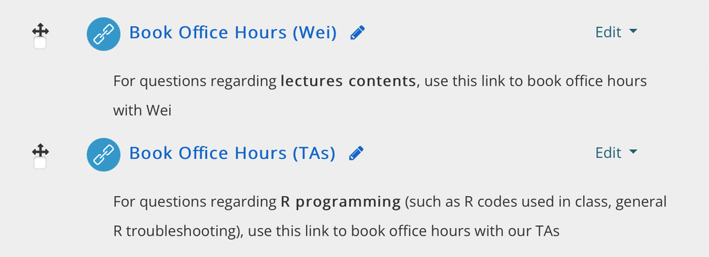

## 5 About R Programming

- **Please bring your laptops in all classes.** There will be R exercises in class every week.
- It’s totally normal to feel overwhelmed in the first few weeks from learning R.
- If you run into any problems with R
  - [“Common R Programming Errors Faced by Beginners”](https://weim-mkt.github.io/UCLMarketingAnalytics/R-errors.html); I will constantly update this page based on your questions, so this should be the first place to look for an answer
  - Google and ChatGPT are always your best places to seek answers for most debugging issues
  - Office hours with TAs

## 6 Classroom Etiquette

- **Class participation**
  - Please remember to bring you name tags. Please let me know how to pronounce your name correctly.
- **Attendance**
  - School will track your attendance per university policy
  - Please email me if you couldn’t attend a class

## 7 10-week Contract between Us

- **I promise**
  - I will teach you the “science” part of marketing including the state-of-the-art marketing analytics tools
  - You will be in a position to intelligently manage and benefit from marketing analytics people (without turning you into a statistician)
  - Give you a way of thinking about how to use data analytics tools to solve business problems in the future, not just marketing, not just today
  - Accessible when you need help
- **You promise**
  - Duly prepared for each class
  - Attend classes regularly